# Data Analysis for Study 5

# Study 5 Introduction

This Markdown documents the process to analyze the data for Study 5 which looked at the difference between those who received and those who did ./not receive a warning at the beginning of the study for a new population: experts. Experts were PhD students from humanities and quantitative fields.

This HTML was last knitted on: 2020-09-21 17:00:02

## Set Up

### Packages and Libraries

You must run this section before you can run any other chunks.

### Exclusions

You can exclude subjects who did not get the correct answer in the exercise by changing Exclude_Exercise_Check (line 97) to TRUE. The next time you run all the code, these participants will be excluded.

For this report, **no** participants are being excluded from analysis.

#### Spontaneously noticed manipulation

To exclude participants who spontaneously noticed the manipulation, set the following chunk to TRUE.

| noticed | n |
| --- | --- |
| 1 | 24 |

| field | n |
| --- | --- |
| Humanities | 8 |
| Quantitative | 16 |

## Create data frames that will be used throughout

## Methods

### Participants

| field | dem_gender | n |
| --- | --- | --- |
| humanities | female | 109 |
| humanities | male | 51 |
| humanities | non-binary | 5 |
| quantitative | female | 81 |
| quantitative | male | 82 |
| quantitative | non-binary | 2 |

| field | mean_age | sd_age | median_age | min_age | max_age | range_age |
| --- | --- | --- | --- | --- | --- | --- |
| humanities | 28.97531 | 4.467899 | 28 | 22 | 48 | 26 |
| quantitative | 26.86585 | 3.583405 | 26 | 21 | 41 | 20 |

165 PhD students (81 women, 2 non-binary gender; M<sub>age</sub> = 26.87 years, SD<sub>age</sub> = 3.58) in the departments of Statistics, Psychology, and Economics and 165 (109 women, 5 non-binary gender; M<sub>age</sub> = 28.98 years, SD<sub>age</sub> = 4.47) in the departments of History and English participated in Study 5.

Using publicly available email addresses, and after consulting with the universities’ review boards, we recruited PhD students from the top programs in these fields. A list of schools we recruited from is available in our Supplemental Information.

| field | n | mean | sd | median | min | max | range | alpha |
| --- | --- | --- | --- | --- | --- | --- | --- | --- |
| humanities | 165 | 37.58537 | 8.419159 | 38 | 15 | 57 | 42 | 0.89 |
| quantitative | 165 | 45.79394 | 7.181868 | 46 | 20 | 60 | 40 | 0.89 |

Both reports of formal statistical training and the graph literacy scale scores support our assumptions about the two populations: Participants from the quantitative sample scored higher on the graph literacy measure (M = 45.79, SD~graph literacy~= 7.18) than did participants from the humanities (M = 37.59, SD~graph literacy~= 8.42).

```
##
##  Two Sample t-test
##
## data:  graphliteracy_sum_rating by field
## t = -9.516, df = 327, p-value < 0.00000000000000022
## alternative hypothesis: true difference in means is not equal to 0
## 95 percent confidence interval:
##  -9.905537 -6.511610
## sample estimates:
##   mean in group humanities mean in group quantitative
##                   37.58537                   45.79394
```

```
##
## Cohen's d
##
## d estimate: 1.048765 (large)
## 95 percent confidence interval:
##       inf       sup
## 0.8174173 1.2801133
```

The difference in graph literacy between these samples is statistically significant with a large effect size: t(327) = 9.52, p < 0.00, d = 1.05

We use a sample of PhD students from the fields of psychology, statistics, and economics with the rationale that these fields require that students regularly read and produce graphs. 92.12% of the participants from this sample reported having formal statistical training. We also used a sample of PhD students from English and History departments, assuming that these students have a lower exposure to graphs. In fitting with our recruitment strategy, only 7.27% of the participants from this sample reported having formal statistical training.

```
##
##  Pearson's Chi-squared test
##
## data:  demographic_df$field and demographic_df$dem_stat_formal
## X-squared = 237.58, df = 1, p-value < 0.00000000000000022
```

### Exercise Check

97.55% of all participants in the warning condition answered the training exercise question correctly.

97.5% of the humanities participants in the warning condition answered the training exercise question correctly.

97.59% of the quantitative participants in the warning condition answered the training exercise question correctly.

For this report, no participants are being excluded from analysis. If you want to see results when participants who got the exercise wrong are excluded/included, you can go to the section called Exclusions (at the top of this file) and change **Exclude_Exercise_Check <- TRUE**

## Results

### The truncation effect

We first replicated the truncation effect found in Studies 1 through 4.

| graph_condition | n | mean | sd | median | min | max | range |
| --- | --- | --- | --- | --- | --- | --- | --- |
| control | 330 | 3.730335 | 0.5436076 | 3.650 | 2.3 | 5.8 | 3.5 |
| truncated | 330 | 4.165526 | 0.7572225 | 4.125 | 2.2 | 6.9 | 4.7 |

We found that average ratings of differences for truncated graphs was higher than ratings for control graphs: M<sub>control</sub> = 3.73, SD = 0.54; M<sub>truncated</sub> = 4.17, SD = 0.76.

```
##
## Cohen's d
##
## d estimate: -0.4768741 (small)
## 95 percent confidence interval:
##        inf        sup
## -0.6318958 -0.3218525
```

```
##
##  Paired t-test
##
## data:  subject_mean_rating by graph_condition
## t = -13.902, df = 329, p-value < 0.00000000000000022
## alternative hypothesis: true difference in means is not equal to 0
## 95 percent confidence interval:
##  -0.4967726 -0.3736083
## sample estimates:
## mean of the differences
##              -0.4351904
```

This main effect was statistically significant: t(329) = 13.9, p < 6.963037e-35, 95% CI of difference = [0.37, 0.50], d = 0.48. .

| field | direction | n | percentage |
| --- | --- | --- | --- |
| humanities | expected | 129 | 78.18182 |
| humanities | unexpected | 36 | 21.81818 |
| quantitative | expected | 124 | 75.15152 |
| quantitative | unexpected | 41 | 24.84848 |

As before, most participants from both fields showed an overall truncation effect:78.18% of participants from the humanities group, and 75.15% in the quantitative group.

### Check model assumptions

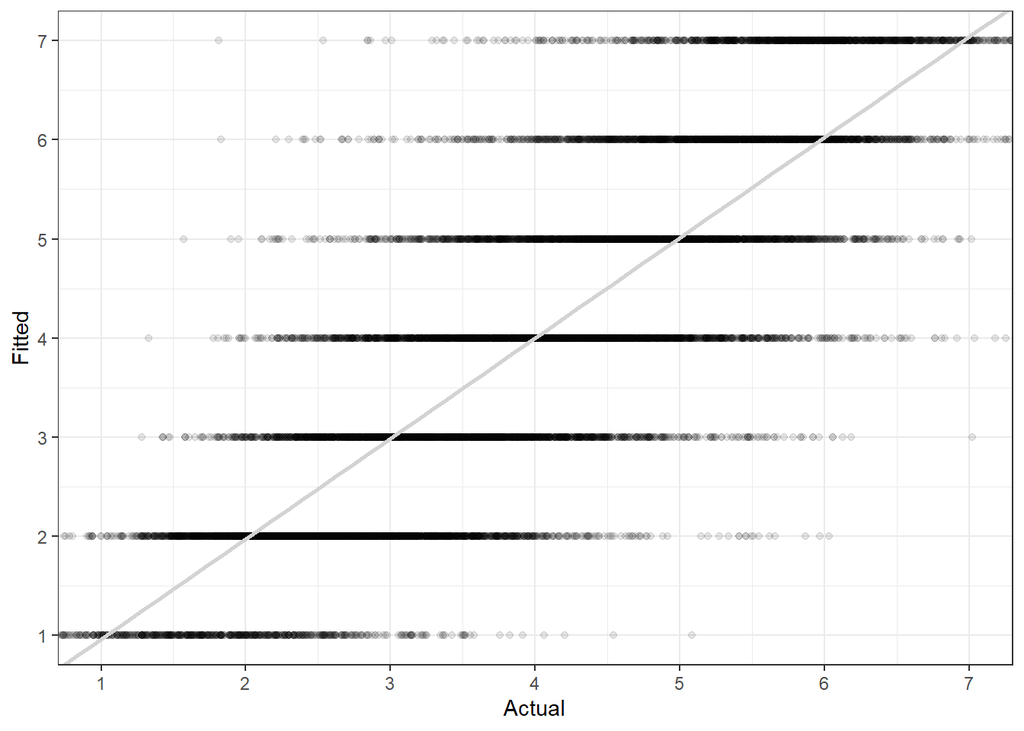

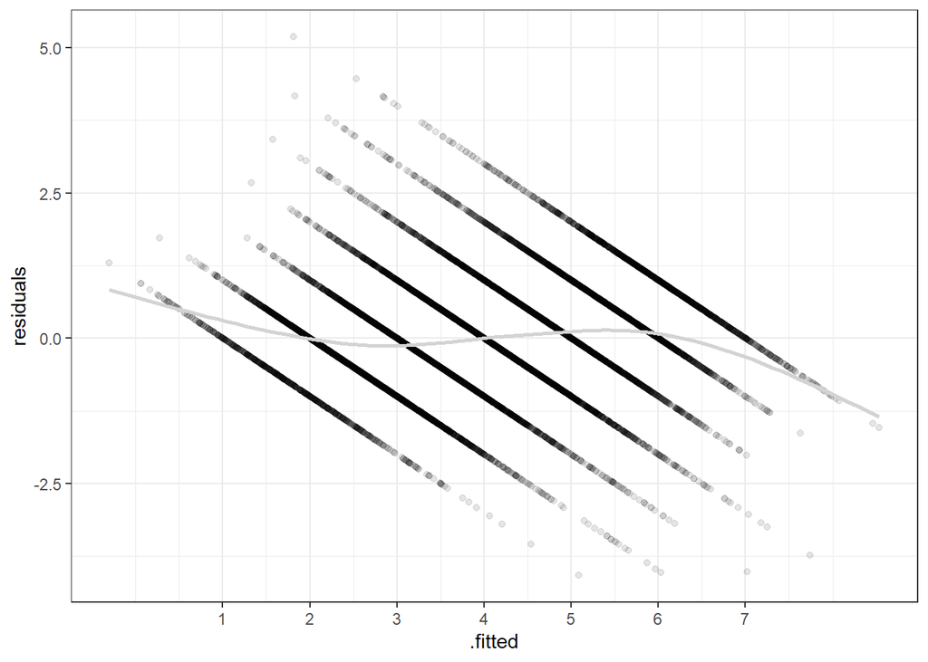

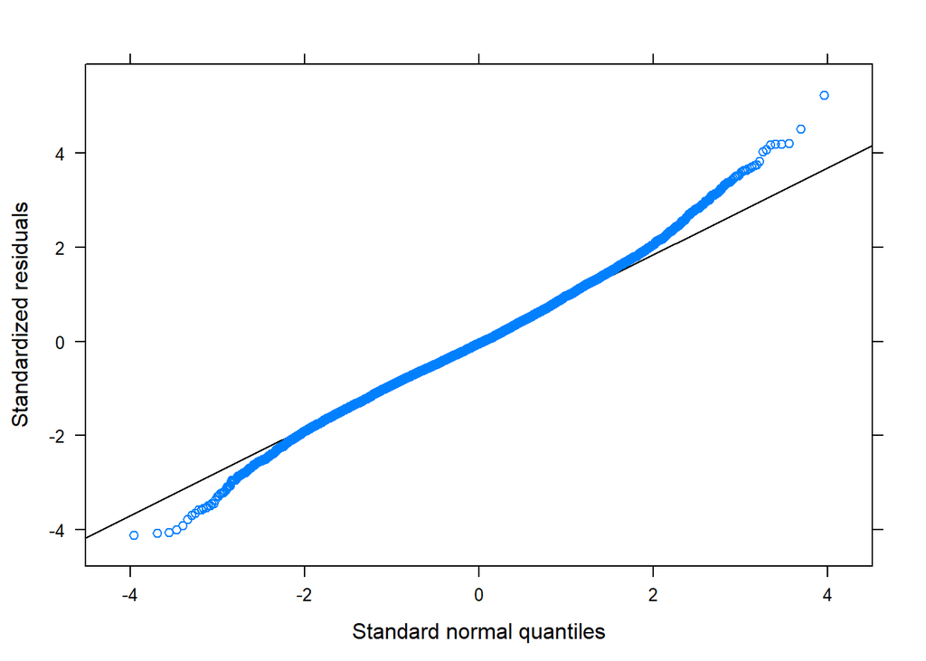

Table 3

| Row.names | Estimate | 95% CI of Estimate | Std. Error | t value | Pr(>\|t\|) |
| --- | --- | --- | --- | --- | --- |
| (Intercept) | 3.90 | [3.49,4.32] | 0.21 | 18.22 | 0.00 |
| fieldquantitative | -0.20 | [-0.37,-0.03] | 0.09 | -2.19 | 0.03 |
| graph_conditiontruncated | 0.69 | [0.62,0.76] | 0.03 | 20.30 | 0.00 |
| graph_conditiontruncated:fieldquantitative | -0.14 | [-0.24,-0.04] | 0.05 | -2.97 | 0.00 |
| subject_conditionwarning | -0.30 | [-0.47,-0.11] | 0.09 | -3.31 | 0.00 |
| subject_conditionwarning:fieldquantitative | 0.32 | [0.06,0.57] | 0.13 | 2.47 | 0.01 |
| subject_conditionwarning:graph_conditiontruncated | -0.42 | [-0.51,-0.32] | 0.05 | -8.59 | 0.00 |
| subject_conditionwarning:graph_conditiontruncated:fieldquantitative | 0.10 | [-0.04,0.24] | 0.07 | 1.50 | 0.13 |

## Follow-up analyses

First, visualize the interaction:

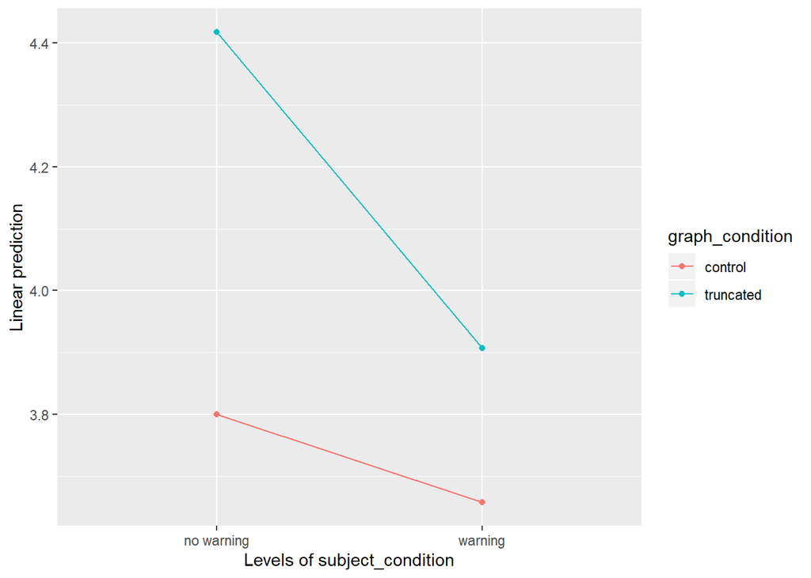

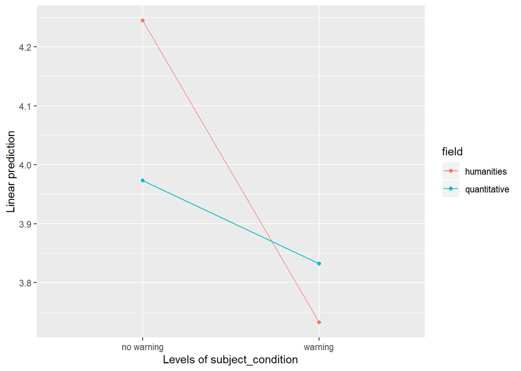

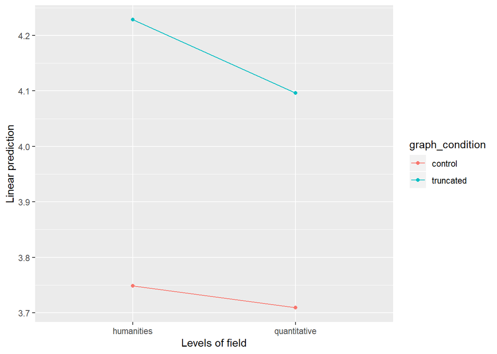

```
## $emmeans
## graph_condition = control:
##  field        emmean    SE  df asymp.LCL asymp.UCL
##  humanities     3.75 0.209 Inf      3.34      4.16
##  quantitative   3.71 0.209 Inf      3.30      4.12
##
## graph_condition = truncated:
##  field        emmean    SE  df asymp.LCL asymp.UCL
##  humanities     4.23 0.209 Inf      3.82      4.64
##  quantitative   4.10 0.209 Inf      3.69      4.51
##
## Results are averaged over the levels of: subject_condition
## Degrees-of-freedom method: asymptotic
## Confidence level used: 0.95
##
## $contrasts
## graph_condition = control:
##  contrast                  estimate     SE  df z.ratio p.value
##  humanities - quantitative   0.0394 0.0646 Inf 0.610   0.5419
##
## graph_condition = truncated:
##  contrast                  estimate     SE  df z.ratio p.value
##  humanities - quantitative   0.1319 0.0646 Inf 2.043   0.0410
##
## Results are averaged over the levels of: subject_condition
## Degrees-of-freedom method: asymptotic
```

|  | contrast | graph_condition | estimate | SE | df | asymp.LCL | asymp.UCL |
| --- | --- | --- | --- | --- | --- | --- | --- |
| 1 | humanities - quantitative | control | 0.03938668 | 0.06457922 | Inf | -0.087186258 | 0.1659596 |
| 2 | humanities - quantitative | truncated | 0.13194955 | 0.06457948 | Inf | 0.005376089 | 0.2585230 |

```
## $emmeans
## field = humanities:
##  graph_condition emmean    SE  df asymp.LCL asymp.UCL
##  control           3.75 0.209 Inf      3.34      4.16
##  truncated         4.23 0.209 Inf      3.82      4.64
##
## field = quantitative:
##  graph_condition emmean    SE  df asymp.LCL asymp.UCL
##  control           3.71 0.209 Inf      3.30      4.12
##  truncated         4.10 0.209 Inf      3.69      4.51
##
## Results are averaged over the levels of: subject_condition
## Degrees-of-freedom method: asymptotic
## Confidence level used: 0.95
##
## $contrasts
## field = humanities:
##  contrast            estimate     SE  df z.ratio p.value
##  control - truncated   -0.480 0.0244 Inf -19.660 <.0001
##
## field = quantitative:
##  contrast            estimate     SE  df z.ratio p.value
##  control - truncated   -0.387 0.0244 Inf -15.857 <.0001
##
## Results are averaged over the levels of: subject_condition
## Degrees-of-freedom method: asymptotic
```

```
## $emmeans
## field = humanities:
##  graph_condition emmean    SE  df asymp.LCL asymp.UCL
##  control           3.75 0.209 Inf      3.34      4.16
##  truncated         4.23 0.209 Inf      3.82      4.64
##
## field = quantitative:
##  graph_condition emmean    SE  df asymp.LCL asymp.UCL
##  control           3.71 0.209 Inf      3.30      4.12
##  truncated         4.10 0.209 Inf      3.69      4.51
##
## Results are averaged over the levels of: subject_condition
## Degrees-of-freedom method: asymptotic
## Confidence level used: 0.95
##
## $contrasts
## field = humanities:
##  contrast            estimate     SE  df asymp.LCL asymp.UCL
##  control - truncated   -0.480 0.0244 Inf    -0.528    -0.432
##
## field = quantitative:
##  contrast            estimate     SE  df asymp.LCL asymp.UCL
##  control - truncated   -0.387 0.0244 Inf    -0.435    -0.340
##
## Results are averaged over the levels of: subject_condition
## Degrees-of-freedom method: asymptotic
## Confidence level used: 0.95
```

```
##  contrast
##  (control - truncated humanities) - (control - truncated quantitative)
##  estimate     SE  df z.ratio p.value
##   -0.0926 0.0346 Inf -2.679  0.0074
##
## Results are averaged over the levels of: subject_condition
## Degrees-of-freedom method: asymptotic
```

|  | contrast | estimate | SE | df | asymp.LCL | asymp.UCL |
| --- | --- | --- | --- | --- | --- | --- |
| 1 | (control - truncated humanities) - (control - truncated quantitative) | -0.09256287 | 0.03455244 | Inf | -0.1602844 | -0.02484134 |

```
## $emmeans
## subject_condition = no warning:
##  field        emmean    SE  df asymp.LCL asymp.UCL
##  humanities     4.24 0.213 Inf      3.83      4.66
##  quantitative   3.97 0.214 Inf      3.55      4.39
##
## subject_condition = warning:
##  field        emmean    SE  df asymp.LCL asymp.UCL
##  humanities     3.73 0.214 Inf      3.31      4.15
##  quantitative   3.83 0.214 Inf      3.41      4.25
##
## Results are averaged over the levels of: graph_condition
## Degrees-of-freedom method: asymptotic
## Confidence level used: 0.95
##
## $contrasts
## subject_condition = no warning:
##  contrast                  estimate     SE  df z.ratio p.value
##  humanities - quantitative   0.2712 0.0875 Inf  3.100  0.0019
##
## subject_condition = warning:
##  contrast                  estimate     SE  df z.ratio p.value
##  humanities - quantitative  -0.0998 0.0885 Inf -1.127  0.2595
##
## Results are averaged over the levels of: graph_condition
## Degrees-of-freedom method: asymptotic
```

```
## $emmeans
## subject_condition = no warning:
##  field        emmean    SE  df asymp.LCL asymp.UCL
##  humanities     4.24 0.213 Inf      3.83      4.66
##  quantitative   3.97 0.214 Inf      3.55      4.39
##
## subject_condition = warning:
##  field        emmean    SE  df asymp.LCL asymp.UCL
##  humanities     3.73 0.214 Inf      3.31      4.15
##  quantitative   3.83 0.214 Inf      3.41      4.25
##
## Results are averaged over the levels of: graph_condition
## Degrees-of-freedom method: asymptotic
## Confidence level used: 0.95
##
## $contrasts
## subject_condition = no warning:
##  contrast                  estimate     SE  df asymp.LCL asymp.UCL
##  humanities - quantitative   0.2712 0.0875 Inf    0.0997    0.4426
##
## subject_condition = warning:
##  contrast                  estimate     SE  df asymp.LCL asymp.UCL
##  humanities - quantitative  -0.0998 0.0885 Inf   -0.2733    0.0737
##
## Results are averaged over the levels of: graph_condition
## Degrees-of-freedom method: asymptotic
## Confidence level used: 0.95
```

```
## $emmeans
## field = humanities:
##  subject_condition emmean    SE  df asymp.LCL asymp.UCL
##  no warning          4.24 0.213 Inf      3.83      4.66
##  warning             3.73 0.214 Inf      3.31      4.15
##
## field = quantitative:
##  subject_condition emmean    SE  df asymp.LCL asymp.UCL
##  no warning          3.97 0.214 Inf      3.55      4.39
##  warning             3.83 0.214 Inf      3.41      4.25
##
## Results are averaged over the levels of: graph_condition
## Degrees-of-freedom method: asymptotic
## Confidence level used: 0.95
##
## $contrasts
## field = humanities:
##  contrast             estimate    SE  df z.ratio p.value
##  no warning - warning    0.512 0.088 Inf 5.820   <.0001
##
## field = quantitative:
##  contrast             estimate    SE  df z.ratio p.value
##  no warning - warning    0.141 0.088 Inf 1.606   0.1084
##
## Results are averaged over the levels of: graph_condition
## Degrees-of-freedom method: asymptotic
```

```
## $emmeans
## field = humanities:
##  subject_condition emmean    SE  df asymp.LCL asymp.UCL
##  no warning          4.24 0.213 Inf      3.83      4.66
##  warning             3.73 0.214 Inf      3.31      4.15
##
## field = quantitative:
##  subject_condition emmean    SE  df asymp.LCL asymp.UCL
##  no warning          3.97 0.214 Inf      3.55      4.39
##  warning             3.83 0.214 Inf      3.41      4.25
##
## Results are averaged over the levels of: graph_condition
## Degrees-of-freedom method: asymptotic
## Confidence level used: 0.95
##
## $contrasts
## field = humanities:
##  contrast             estimate    SE  df asymp.LCL asymp.UCL
##  no warning - warning    0.512 0.088 Inf    0.3397     0.685
##
## field = quantitative:
##  contrast             estimate    SE  df asymp.LCL asymp.UCL
##  no warning - warning    0.141 0.088 Inf   -0.0312     0.314
##
## Results are averaged over the levels of: graph_condition
## Degrees-of-freedom method: asymptotic
## Confidence level used: 0.95
```

```
##  contrast
##  (humanities - quantitative no warning) - (humanities - quantitative warning)
##  estimate    SE  df z.ratio p.value
##     0.371 0.124 Inf 2.981   0.0029
##
## Results are averaged over the levels of: graph_condition
## Degrees-of-freedom method: asymptotic
```

|  | contrast | estimate | SE | df | asymp.LCL | asymp.UCL |
| --- | --- | --- | --- | --- | --- | --- |
| 1 | (humanities - quantitative no warning) - (humanities - quantitative warning) | 0.3709639 | 0.1244512 | Inf | 0.1270441 | 0.6148838 |

```
## $emmeans
## subject_condition = no warning:
##  graph_condition emmean    SE  df asymp.LCL asymp.UCL
##  control           3.80 0.209 Inf      3.39      4.21
##  truncated         4.42 0.209 Inf      4.01      4.83
##
## subject_condition = warning:
##  graph_condition emmean    SE  df asymp.LCL asymp.UCL
##  control           3.66 0.209 Inf      3.25      4.07
##  truncated         3.91 0.209 Inf      3.50      4.32
##
## Results are averaged over the levels of: field
## Degrees-of-freedom method: asymptotic
## Confidence level used: 0.95
##
## $contrasts
## subject_condition = no warning:
##  contrast            estimate     SE  df z.ratio p.value
##  control - truncated   -0.618 0.0243 Inf -25.420 <.0001
##
## subject_condition = warning:
##  contrast            estimate     SE  df z.ratio p.value
##  control - truncated   -0.250 0.0246 Inf -10.170 <.0001
##
## Results are averaged over the levels of: field
## Degrees-of-freedom method: asymptotic
```

```
## $emmeans
## subject_condition = no warning:
##  graph_condition emmean    SE  df asymp.LCL asymp.UCL
##  control           3.80 0.209 Inf      3.39      4.21
##  truncated         4.42 0.209 Inf      4.01      4.83
##
## subject_condition = warning:
##  graph_condition emmean    SE  df asymp.LCL asymp.UCL
##  control           3.66 0.209 Inf      3.25      4.07
##  truncated         3.91 0.209 Inf      3.50      4.32
##
## Results are averaged over the levels of: field
## Degrees-of-freedom method: asymptotic
## Confidence level used: 0.95
##
## $contrasts
## subject_condition = no warning:
##  contrast            estimate     SE  df asymp.LCL asymp.UCL
##  control - truncated   -0.618 0.0243 Inf    -0.665    -0.570
##
## subject_condition = warning:
##  contrast            estimate     SE  df asymp.LCL asymp.UCL
##  control - truncated   -0.250 0.0246 Inf    -0.298    -0.202
##
## Results are averaged over the levels of: field
## Degrees-of-freedom method: asymptotic
## Confidence level used: 0.95
```

```
## $emmeans
## graph_condition = control:
##  subject_condition emmean    SE  df asymp.LCL asymp.UCL
##  no warning          3.80 0.209 Inf      3.39      4.21
##  warning             3.66 0.209 Inf      3.25      4.07
##
## graph_condition = truncated:
##  subject_condition emmean    SE  df asymp.LCL asymp.UCL
##  no warning          4.42 0.209 Inf      4.01      4.83
##  warning             3.91 0.209 Inf      3.50      4.32
##
## Results are averaged over the levels of: field
## Degrees-of-freedom method: asymptotic
## Confidence level used: 0.95
##
## $contrasts
## graph_condition = control:
##  contrast             estimate     SE  df z.ratio p.value
##  no warning - warning    0.143 0.0646 Inf 2.212   0.0270
##
## graph_condition = truncated:
##  contrast             estimate     SE  df z.ratio p.value
##  no warning - warning    0.511 0.0646 Inf 7.907   <.0001
##
## Results are averaged over the levels of: field
## Degrees-of-freedom method: asymptotic
```

```
## $emmeans
## graph_condition = control:
##  subject_condition emmean    SE  df asymp.LCL asymp.UCL
##  no warning          3.80 0.209 Inf      3.39      4.21
##  warning             3.66 0.209 Inf      3.25      4.07
##
## graph_condition = truncated:
##  subject_condition emmean    SE  df asymp.LCL asymp.UCL
##  no warning          4.42 0.209 Inf      4.01      4.83
##  warning             3.91 0.209 Inf      3.50      4.32
##
## Results are averaged over the levels of: field
## Degrees-of-freedom method: asymptotic
## Confidence level used: 0.95
##
## $contrasts
## graph_condition = control:
##  contrast             estimate     SE  df asymp.LCL asymp.UCL
##  no warning - warning    0.143 0.0646 Inf    0.0163     0.269
##
## graph_condition = truncated:
##  contrast             estimate     SE  df asymp.LCL asymp.UCL
##  no warning - warning    0.511 0.0646 Inf    0.3841     0.637
##
## Results are averaged over the levels of: field
## Degrees-of-freedom method: asymptotic
## Confidence level used: 0.95
```

```
##  contrast
##  (no warning - warning control) - (no warning - warning truncated)
##  estimate     SE  df z.ratio p.value
##    -0.368 0.0346 Inf -10.638 <.0001
##
## Results are averaged over the levels of: field
## Degrees-of-freedom method: asymptotic
```

|  | contrast | estimate | SE | df | asymp.LCL | asymp.UCL |
| --- | --- | --- | --- | --- | --- | --- |
| 1 | (no warning - warning control) - (no warning - warning truncated) | -0.3677908 | 0.03457282 | Inf | -0.4355522 | -0.3000293 |

Plot the comparisons graphically. Blue bars are CIs for the EMMs, which should not be used for comparisons. Red arrows are for comparisons among them. However, this plot shows a discrepancy between the model and the arrows.

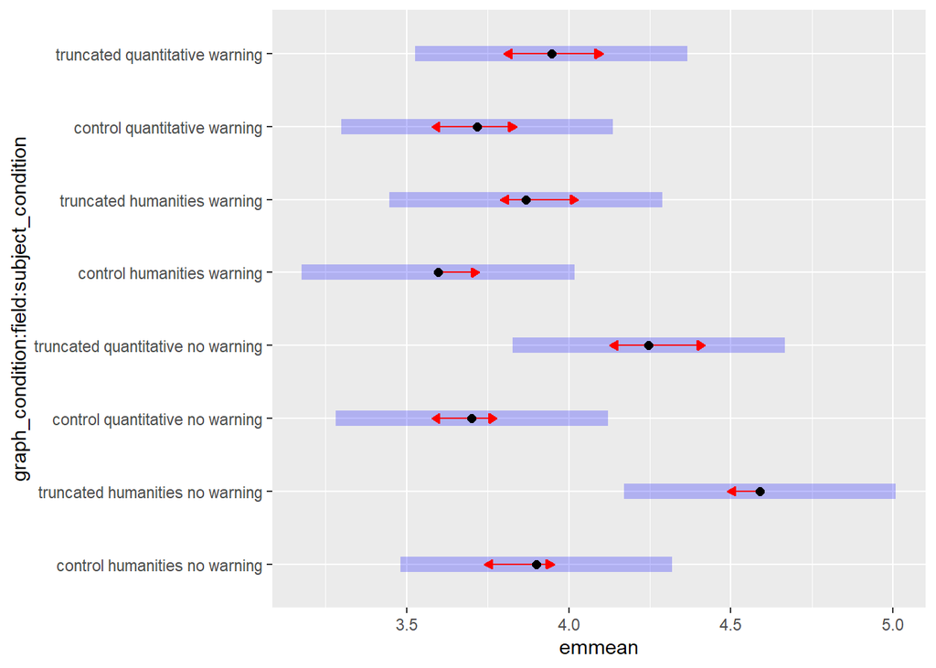

## Figure 8

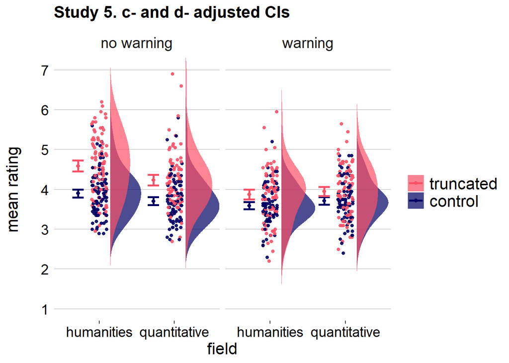

| level1 | level2 | estimate | std.error | df | z.ratio | p.value |
| --- | --- | --- | --- | --- | --- | --- |
| control humanities no warning | truncated humanities no warning | -0.68974669 | 0.03397333 | Inf | -20.3025930 | 0.00000000000000000000 |
| control humanities no warning | control quantitative no warning | 0.19899199 | 0.09078193 | Inf | 2.1919779 | 0.35646727537000011399 |
| control humanities no warning | truncated quantitative no warning | -0.34643853 | 0.09077573 | Inf | -3.8164225 | 0.00339549200453204136 |
| control humanities no warning | control humanities warning | 0.30246207 | 0.09133574 | Inf | 3.3115413 | 0.02087214547889171268 |
| control humanities no warning | truncated humanities warning | 0.03225944 | 0.09133917 | Inf | 0.3531829 | 0.99996777600344222137 |
| control humanities no warning | control quantitative warning | 0.18224345 | 0.09047632 | Inf | 2.0142668 | 0.47203840952539033449 |
| control humanities no warning | truncated quantitative warning | -0.04714962 | 0.09047503 | Inf | -0.5211341 | 0.99955849807877805713 |
| truncated humanities no warning | control quantitative no warning | 0.88873868 | 0.09078292 | Inf | 9.7897126 | 0.00000000000008393286 |
| truncated humanities no warning | truncated quantitative no warning | 0.34330816 | 0.09078221 | Inf | 3.7816678 | 0.00388481886944824772 |
| truncated humanities no warning | control humanities warning | 0.99220877 | 0.09134038 | Inf | 10.8627621 | 0.00000000000007882583 |

[output cut: 18 more lines]

control,quantitative,warning - truncated,quantitative,warning estimate= -0.22939307 SE = 0.03439020 z.ratio = -6.6703037 p = 0.00000000071444516969

```
##
##  Paired t-test
##
## data:  subject_mean_rating by graph_condition
## t = -4.7199, df = 82, p-value = 0.000009596
## alternative hypothesis: true difference in means is not equal to 0
## 95 percent confidence interval:
##  -0.3350873 -0.1363775
## sample estimates:
## mean of the differences
##              -0.2357324
```

# Supplemental Information

## Methods (Supplemental Information)

### Participants (Supplemental Information)

216 participants reported English as their first language, 109 reported a different first language. Below is a list of all the languages that were reported.

| dem_language_other | n |
| --- | --- |
| bengali | 1 |
| cantonese | 1 |
| chinese | 21 |
| english | 1 |
| french | 5 |
| german | 3 |
| greek | 3 |
| hebrew | 1 |
| hindi | 1 |
| hungarian | 1 |

[output cut: 17 more lines]

| dem_ed | n | percentage |
| --- | --- | --- |
| 2 | 1 | 0.3030303 |
| 4 | 1 | 0.3030303 |
| 6 | 18 | 5.4545455 |
| 7 | 123 | 37.2727273 |
| 8 | 187 | 56.6666667 |

As expected 99% of participants reported having at least a Bachelorâs degree and 94% reported Completion of some graduate school courses or holding a Graduate degree.

We recruited from PhD students from these schools:

| dem_school | n() |
| --- | --- |
| Brown University | 23 |
| CMU | 8 |
| Duke | 16 |
| Duke University | 11 |
| Harvard | 9 |
| John Hopkins | 11 |
| Stanford | 26 |
| U. Wash St. Louis | 13 |
| UC Berkeley | 31 |
| UMichigan | 50 |

[output cut: 3 more lines]

| dem_school | field | n() |
| --- | --- | --- |
| Brown University | humanities | 11 |
| Brown University | quantitative | 12 |
| CMU | humanities | 5 |
| CMU | quantitative | 3 |
| Duke | humanities | 16 |
| Duke University | quantitative | 11 |
| Harvard | humanities | 5 |
| Harvard | quantitative | 4 |
| John Hopkins | humanities | 6 |
| John Hopkins | quantitative | 5 |

[output cut: 11 more lines]

| field | mean_duration | sd_duration | median_duration | min_duration | max_duration | range_duration |
| --- | --- | --- | --- | --- | --- | --- |
| humanities | 238.5868 | 930.4125 | 20.03333 | 7.450000 | 6900.900 | 6893.45 |
| quantitative | 391.6671 | 1429.7164 | 20.88333 | 5.816667 | 8670.117 | 8664.30 |

The experiment took participants from the humanities fields an average of M<sub>duration</sub> = 238.59 minutes, (SD<sub>duration</sub> = 930.41 minutes).

The experiment took participants from the quantitative fields an average of M<sub>duration</sub> = 391.67 minutes, (SD<sub>duration</sub> = 1429.72 minutes).

### Statistical Training (Supplemental Information)

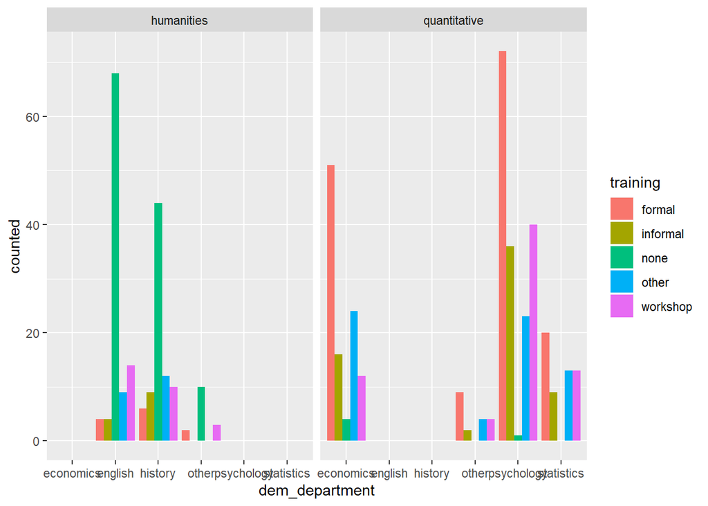

## Results (Supplemental Information)

#### Model Comparisons

This function as omnibus tests for main effects.

##### Warning Condition

The model including warning condition is statistically different than the model without field

|  | npar | AIC | BIC | logLik | deviance | Chisq | Df | Pr(>Chisq) |
| --- | --- | --- | --- | --- | --- | --- | --- | --- |
| model_nowarningcondition | 6 | 50839.77 | 50884.69 | -25413.89 | 50827.77 | NA | NA | NA |
| model_full | 11 | 38252.82 | 38335.17 | -19115.41 | 38230.82 | 12596.95 | 5 | 0 |

##### 3-way interaction

|  | npar | AIC | BIC | logLik | deviance | Chisq | Df | Pr(>Chisq) |
| --- | --- | --- | --- | --- | --- | --- | --- | --- |
| model_no3way | 9 | 50772.53 | 50839.91 | -25377.27 | 50754.53 | NA | NA | NA |
| model_full | 11 | 38252.82 | 38335.17 | -19115.41 | 38230.82 | 12523.71 | 2 | 0 |

##### 2-way interactions

###### Evaluating graph:warning

Statistically significant (p < .0001)

|  | npar | AIC | BIC | logLik | deviance | Chisq | Df | Pr(>Chisq) |
| --- | --- | --- | --- | --- | --- | --- | --- | --- |
| model_nographwarning | 8 | 50808.96 | 50868.85 | -25396.48 | 50792.96 | NA | NA | NA |
| model_no3way | 9 | 50772.53 | 50839.91 | -25377.27 | 50754.53 | 38.42672 | 1 | 0.0000000005684883 |

###### Evaluating field:graph type

Not statistically different at alpha = .05 (p = .065)

|  | npar | AIC | BIC | logLik | deviance | Chisq | Df | Pr(>Chisq) |
| --- | --- | --- | --- | --- | --- | --- | --- | --- |
| model_nographfield | 8 | 50773.94 | 50833.83 | -25378.97 | 50757.94 | NA | NA | NA |
| model_no3way | 9 | 50772.53 | 50839.91 | -25377.27 | 50754.53 | 3.406386 | 1 | 0.06494455 |

###### Evaluating field:warning

Statistically different at p = .003

|  | npar | AIC | BIC | logLik | deviance | Chisq | Df | Pr(>Chisq) |
| --- | --- | --- | --- | --- | --- | --- | --- | --- |
| model_nofieldwarning | 8 | 50779.62 | 50839.51 | -25381.81 | 50763.62 | NA | NA | NA |
| model_no3way | 9 | 50772.53 | 50839.91 | -25377.27 | 50754.53 | 9.087459 | 1 | 0.002573682 |

#### Graph literacy

##### Main Effect

Graph literacy does not explain the size of the truncation effect:

```
##
## Call:
## lm(formula = difference ~ graphliteracy_sum_rating, data = models_difference_df)
##
## Residuals:
##      Min       1Q   Median       3Q      Max
## -2.29465 -0.39465 -0.00976  0.32718  1.89248
##
## Coefficients:
##                          Estimate Std. Error t value Pr(>|t|)
## (Intercept)              0.161614   0.151185   1.069   0.2859
## graphliteracy_sum_rating 0.006530   0.003547   1.841   0.0665 .
## ---
## Signif. codes:  0 '***' 0.001 '**' 0.01 '*' 0.05 '.' 0.1 ' ' 1
##
## Residual standard error: 0.567 on 327 degrees of freedom
##   (1 observation deleted due to missingness)
## Multiple R-squared:  0.01026,    Adjusted R-squared:  0.007232
## F-statistic: 3.389 on 1 and 327 DF,  p-value: 0.06652
```

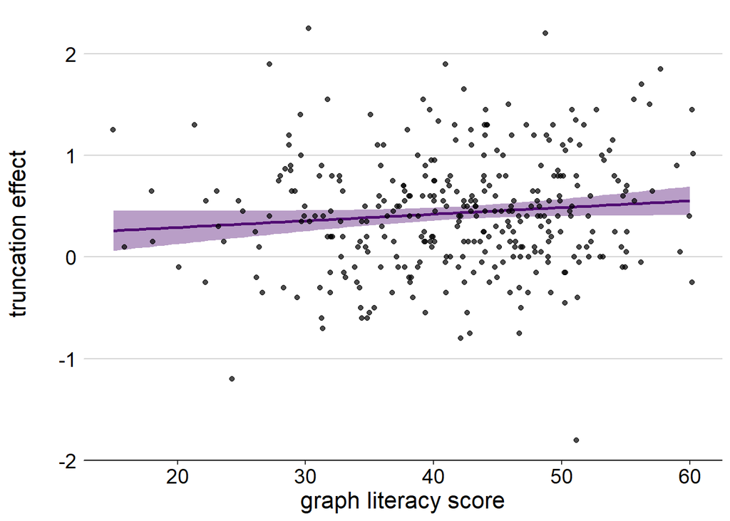

##### Interaction with warning and field

```
##
## Call:
## lm(formula = difference ~ graphliteracy_sum_rating * field *
##     subject_condition, data = models_difference_df)
##
## Residuals:
##      Min       1Q   Median       3Q      Max
## -2.17339 -0.34833 -0.00046  0.31193  1.62274
##
## Coefficients:
##                                                                       Estimate
## (Intercept)                                                          0.4027401
## graphliteracy_sum_rating                                             0.0074841
## fieldquantitative                                                   -0.6082512
## subject_conditionwarning                                            -0.3919428
## graphliteracy_sum_rating:fieldquantitative                           0.0084625
## graphliteracy_sum_rating:subject_conditionwarning                   -0.0003745
## fieldquantitative:subject_conditionwarning                           0.2706230
## graphliteracy_sum_rating:fieldquantitative:subject_conditionwarning -0.0032813
##                                                                     Std. Error
## (Intercept)                                                          0.2616313
## graphliteracy_sum_rating                                             0.0066087
## fieldquantitative                                                    0.4545406
## subject_conditionwarning                                             0.3896016
## graphliteracy_sum_rating:fieldquantitative                           0.0103836
## graphliteracy_sum_rating:subject_conditionwarning                    0.0101746
## fieldquantitative:subject_conditionwarning                           0.6666671
## graphliteracy_sum_rating:fieldquantitative:subject_conditionwarning  0.0154843
##                                                                     t value
## (Intercept)                                                           1.539
## graphliteracy_sum_rating                                              1.132
## fieldquantitative                                                    -1.338
## subject_conditionwarning                                             -1.006
## graphliteracy_sum_rating:fieldquantitative                            0.815
## graphliteracy_sum_rating:subject_conditionwarning                    -0.037
## fieldquantitative:subject_conditionwarning                            0.406
## graphliteracy_sum_rating:fieldquantitative:subject_conditionwarning  -0.212
##                                                                     Pr(>|t|)
## (Intercept)                                                            0.125
## graphliteracy_sum_rating                                               0.258
## fieldquantitative                                                      0.182
## subject_conditionwarning                                               0.315
## graphliteracy_sum_rating:fieldquantitative                             0.416
## graphliteracy_sum_rating:subject_conditionwarning                      0.971
## fieldquantitative:subject_conditionwarning                             0.685
## graphliteracy_sum_rating:fieldquantitative:subject_conditionwarning    0.832
##
## Residual standard error: 0.5358 on 321 degrees of freedom
##   (1 observation deleted due to missingness)
## Multiple R-squared:  0.1323, Adjusted R-squared:  0.1134
## F-statistic: 6.992 on 7 and 321 DF,  p-value: 0.00000009122
```

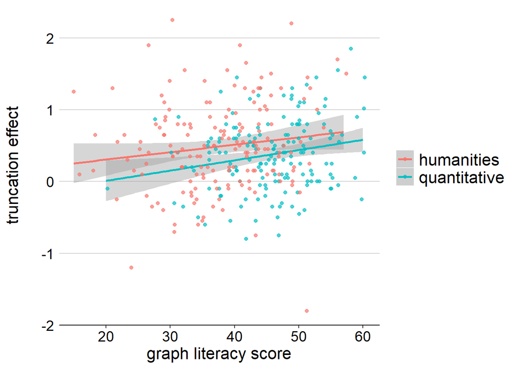

#### Age (Supplemental Information)

```
##
## Call:
## lm(formula = difference ~ dem_age, data = df)
##
## Residuals:
##      Min       1Q   Median       3Q      Max
## -2.23102 -0.37683 -0.02599  0.34474  1.81562
##
## Coefficients:
##             Estimate Std. Error t value Pr(>|t|)
## (Intercept) 0.385748   0.213768   1.805   0.0721 .
## dem_age     0.001677   0.007574   0.221   0.8249
## ---
## Signif. codes:  0 '***' 0.001 '**' 0.01 '*' 0.05 '.' 0.1 ' ' 1
##
## Residual standard error: 0.5703 on 324 degrees of freedom
##   (4 observations deleted due to missingness)
## Multiple R-squared:  0.0001513,  Adjusted R-squared:  -0.002935
## F-statistic: 0.04901 on 1 and 324 DF,  p-value: 0.8249
```

```
##
## Call:
## lm(formula = difference ~ dem_age + field.x + subject_condition.x,
##     data = df)
##
## Residuals:
##      Min       1Q   Median       3Q      Max
## -2.11266 -0.31866 -0.04215  0.34315  1.59503
##
## Coefficients:
##                             Estimate Std. Error t value     Pr(>|t|)
## (Intercept)                 0.716240   0.222101   3.225      0.00139 **
## dem_age                    -0.002113   0.007444  -0.284      0.77673
## field.xquantitative        -0.106486   0.062086  -1.715      0.08728 .
## subject_condition.xwarning -0.346537   0.060076  -5.768 0.0000000188 ***
## ---
## Signif. codes:  0 '***' 0.001 '**' 0.01 '*' 0.05 '.' 0.1 ' ' 1
##
## Residual standard error: 0.5422 on 322 degrees of freedom
##   (4 observations deleted due to missingness)
## Multiple R-squared:  0.1017, Adjusted R-squared:  0.09333
## F-statistic: 12.15 on 3 and 322 DF,  p-value: 0.0000001488
```

#### Timing (Supplemental Information)

Timing information is in seconds.

You can choose to trim or not timing data. By default any timing that is 2 standard deviations away from the mean (for each participant for each condition) is trimmed.

For this report, any timing that is 2 standard deviations away from the mean (for each participant for each condition) WAS trimmed. If you want to see results when participants who got the exercise wrong are excluded/included, you can go to the section called Exclusions (at the top of this file) and change **Trimming <- FALSE**

| field | subject_condition | graph_condition | n | mean | sd | median | min | max | range |
| --- | --- | --- | --- | --- | --- | --- | --- | --- | --- |
| humanities | no warning | control | 85 | 15.25838 | 6.367066 | 13.60830 | 4.011632 | 38.78326 | 34.77163 |
| humanities | no warning | truncated | 85 | 15.53260 | 6.780555 | 13.60850 | 3.707684 | 40.42561 | 36.71793 |
| humanities | warning | control | 80 | 16.19434 | 4.990334 | 15.31986 | 7.145550 | 28.88447 | 21.73892 |
| humanities | warning | truncated | 80 | 17.83274 | 6.657974 | 16.51824 | 7.436737 | 40.43933 | 33.00260 |
| quantitative | no warning | control | 82 | 14.80288 | 6.664436 | 13.44531 | 3.695895 | 43.70405 | 40.00816 |
| quantitative | no warning | truncated | 82 | 15.96553 | 8.073849 | 14.47016 | 3.560947 | 48.47342 | 44.91247 |
| quantitative | warning | control | 83 | 14.34373 | 5.834304 | 13.28437 | 1.514889 | 40.79700 | 39.28211 |
| quantitative | warning | truncated | 83 | 15.42063 | 6.654143 | 14.64695 | 2.786158 | 40.87705 | 38.09089 |

| graph_condition | n | mean | sd | median | min | max | range |
| --- | --- | --- | --- | --- | --- | --- | --- |
| control | 330 | 15.14204 | 6.017592 | 13.93832 | 1.514889 | 43.70405 | 42.18916 |
| truncated | 330 | 16.16962 | 7.099082 | 15.02947 | 2.786158 | 48.47342 | 45.68726 |

| subject_condition | n | mean | sd | median | min | max | range |
| --- | --- | --- | --- | --- | --- | --- | --- |
| no warning | 167 | 15.38995 | 6.975648 | 13.62842 | 3.560947 | 48.47342 | 44.91247 |
| warning | 163 | 15.92824 | 6.181090 | 14.85157 | 1.514889 | 40.87705 | 39.36216 |